# R Notebook

```r
library(tidyverse)
library(CodeClanData)
library(janitor)
```

2 MVP 2.1 Part 1

```r
col_scheme <- c("#E89FE9", "#50434F", "#B6A7B5", "#F9A472", "#BD7040")
```

Question 1. Take the data in the dataset qb_revenue_breakdown and make a stacked bar chart showing the sources of revenue across the two years in the dataset.

[figure not shown]

```r
ggplot(qb_revenue_breakdown) +
  geom_bar(aes(x = Year, y = Revenue, fill = Product), stat = "identity")+
  xlab("\nProduct")+
  ylab("Revenue")+
  ggtitle("Revenue Breakdown",
          subtitle = "2018 - 2019")+
  labs(fill = "Year")+
  scale_fill_manual(values = col_scheme) +
  scale_y_continuous(labels = scales::dollar)+
  theme_light() +
  theme(
    text = element_text(size = 12),
    axis.text = element_text(size = 10),
    axis.title = element_text(size = 12),
    plot.title = element_text(size = 12),
    panel.grid.minor = element_line(colour = "#edf0f5")
  )
```

Question 2. Make a line chart showing monthly sales of the “flagship product” - the ‘KwikBit Unit 1’ - over the last year. This data is inside qb_monthly_sales, but you will need to use filter() or subset() (base R).

[figure not shown]

```r
kwikbit_sales <- clean_names(qb_monthly_sales) %>%
  filter(date >= "2019-01-01" & date <= "2019-12-31") %>%
  filter(cashflow == "Kwikbit Unit 1 Sales")


ggplot(kwikbit_sales)+
         geom_line(
    aes(x = date, y = amount, group = cashflow, colour = cashflow), alpha = 1)+
    xlab("\nMonths")+
  geom_point(aes(x = date, y = amount), alpha = 1) +
  ylab("Amount")+
  ggtitle("Kwikbit Unit 1 Sales",
          subtitle = "2018 - 2019")+
  labs(colour = "Flagship Product") +
  scale_color_manual(values = col_scheme) +
  scale_x_date(date_breaks = "1 month", date_labels = "%b") +
  scale_y_continuous(breaks = seq(500, 700, by = 10),labels = scales::dollar)+
  theme_light() +
  theme(
    text = element_text(size = 12),
    axis.text = element_text(size = 10),
    axis.title = element_text(size = 12),
    plot.title = element_text(size = 12),
    panel.grid.minor = element_line(colour = "#edf0f5")
  )
```

Question 3. Make a line chart showing monthly revenue and costs over the last year. This data is also in qb_monthly_sales.

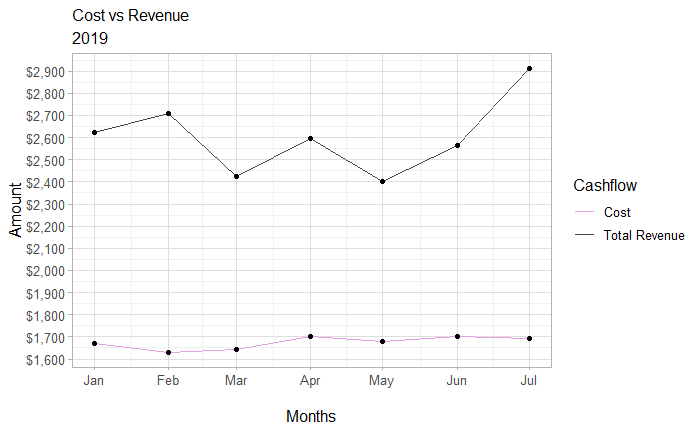

```r
revenue_cost <- clean_names(qb_monthly_sales) %>%
  filter(date >= "2019-01-01" & date <= "2019-12-31") %>%
  filter(cashflow != "Kwikbit Unit 1 Sales")

ggplot(revenue_cost)+
  geom_line(
    aes(x = date, y = amount, group = cashflow, colour = cashflow),alpha = 1)+
  geom_point(aes(x = date, y = amount), alpha = 1) +
  xlab("\nMonths")+
  ylab("Amount")+
  ggtitle("Cost vs Revenue",
          subtitle = "2019")+
  labs(colour = "Cashflow") +
  scale_color_manual(values = col_scheme) +
  scale_x_date(date_breaks = "1 month", date_labels = "%b") +
    scale_y_continuous(breaks = seq(1600, 3000, by = 100),labels = scales::dollar) +
  theme_light() +
  theme(
    text = element_text(size = 12),
    axis.text = element_text(size = 10),
    axis.title = element_text(size = 12),
    plot.title = element_text(size = 12),
    panel.grid.minor = element_line(colour = "#edf0f5")
  )
```

Question 4. Show annual sales of personal fitness trackers over the last 5 years broken down by company as a ribbon plot (use geom_area). This data is in qb_competitors.

```r
qb_competitors
```

| Company | Year | Revenue |
| --- | --- | --- |
| Competitor 1 | 2019 | 2216000 |
| Competitor 2 | 2019 | 1760000 |
| Competitor 3 | 2019 | 1455000 |
| Competitor 4 | 2019 | 1229000 |
| Competitor 1 | 2018 | 2144400 |
| Competitor 2 | 2018 | 1440000 |
| Competitor 3 | 2018 | 1555000 |
| Competitor 4 | 2018 | 987000 |
| Competitor 1 | 2017 | 1750000 |
| Competitor 2 | 2017 | 987000 |

[output cut: 10 more lines]

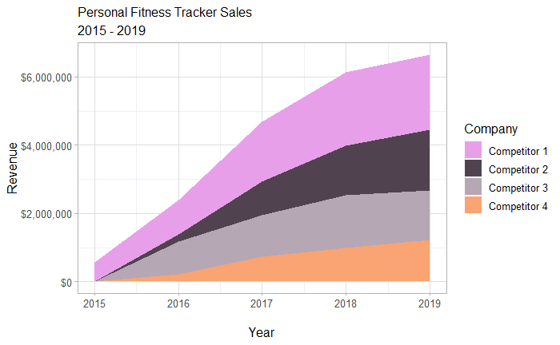

```r
ggplot(qb_competitors)+
  geom_area(aes(x = Year, y = Revenue, fill = Company), stat = "identity")+
  xlab("\nYear")+
  ylab("Revenue")+
  ggtitle("Personal Fitness Tracker Sales",
          subtitle = "2015 - 2019")+
  labs(fill = "Company") +
  scale_fill_manual(values = col_scheme) +
  scale_y_continuous(labels = scales::dollar)+
    theme_light() +
  theme(
    text = element_text(size = 12),
    axis.text = element_text(size = 10),
    axis.title = element_text(size = 12),
    plot.title = element_text(size = 12),
    panel.grid.minor = element_line(colour = "#edf0f5")
  )
```

Question 5. Now show the sales from the four competitors as a line graph. Include an extra layer that shows the data points used to make the lines.

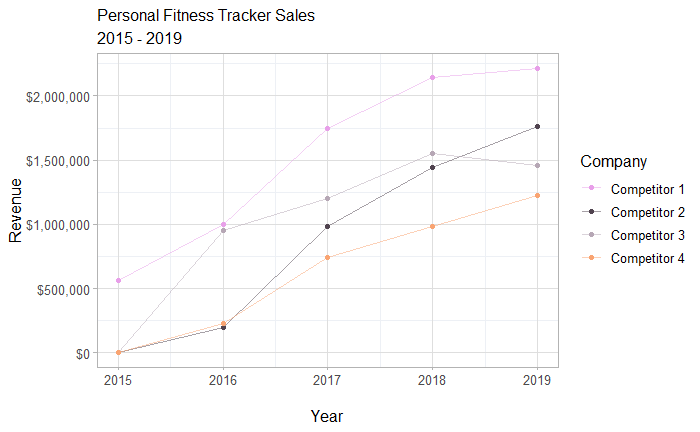

```r
ggplot(qb_competitors) +
  aes(x = Year, y = Revenue, colour = Company) +
  geom_line(aes(group = Company), alpha = 0.5) +
  geom_point(alpha = 1)+
    xlab("\nYear")+
  ylab("Revenue")+
    ggtitle("Personal Fitness Tracker Sales",
          subtitle = "2015 - 2019")+
    labs(fill = "Company") +
  scale_color_manual(values = col_scheme)+
  scale_y_continuous(labels = scales::dollar)+
    theme_light() +
  theme(
    text = element_text(size = 12),
    axis.text = element_text(size = 10),
    axis.title = element_text(size = 12),
    plot.title = element_text(size = 12),
    panel.grid.minor = element_line(colour = "#edf0f5")
  )
```

Question 6. Now the company wants to compare the number of steps that their device counts vs. their competitors. Make a line graph of the number of steps throughout time, and use faceting to compare between companies and people. The data for this is in qb_device_data.

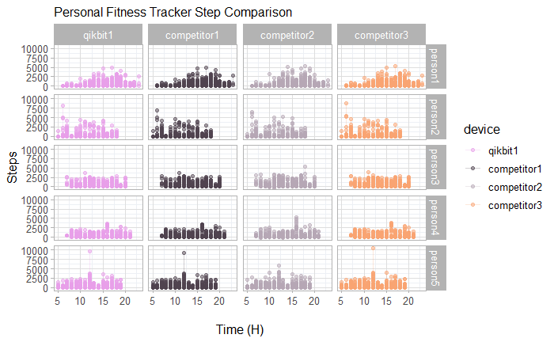

```r
ggplot(qb_device_data) +
  aes(x = hours, y = counts, colour = device)+
geom_line(aes(group = device), alpha = 0.25)+
  geom_point(alpha = 0.5)+
  xlab("\nTime (H)")+
  ylab("Steps")+
    ggtitle("Personal Fitness Tracker Step Comparison")+
    labs(fill = "Company") +
  facet_grid(id ~ device)+
    scale_color_manual(values = col_scheme)+
    theme_light()+
  theme(
    text = element_text(size = 12),
    axis.text = element_text(size = 10),
    axis.title = element_text(size = 12),
    plot.title = element_text(size = 12),
    panel.grid.minor = element_line(colour = "#edf0f5")
  )
```

2.2 Part 2

Question 1. Take the plots that you produced in part one and now polish them by:

```
Adding appropriate labels
Changing the scales and coordinates when appropriate.
Applying a unified theme, which is described below:

Graphs should have white backgrounds, and use colour sparingly.
There should be faint grid lines.
Font sizes should be ~12pt although titles should be slightly larger and axis labels can be slightly smaller.
All plots should use colours from the following company colour scheme.
```